# Tweet Attribution

Trump’s Tweets

Philippe Lambot

February 21, 2021

```r
# Avoiding messages and warnings: anyway, they have already been dealt with.
knitr::opts_chunk$set(echo = TRUE, message = FALSE, warning = FALSE)

# Regulating figure layout.
knitr::opts_chunk$set(out.width = "80%", fig.align = "center")

# Facilitating table layout in HTML.
options(knitr.table.format = "html")

# Output language
invisible(Sys.setlocale("LC_ALL", "C"))
```

Link to R Studio

http://www.rstudio.com

# 1 Executive Summary

**Tweet attribution** is the topic of this project. Tweets come from the account of Candidate Donald Trump during the 2016 presidential election campaign. Two devices have been used to issue tweets: an Android device and an iPhone. The challenge has been to predict the device on the validation set.

Three types of predictors have been used:

- first, differences in **time patterns**, identified through **Exploratory Data Analysis**;
- second, differences in **token frequencies** (unigrams and bigrams), brought out through **Natural Language Processing** and **Text Mining**;
- third, differences in **hyperbolism**, quantified through **Sentiment Analysis**.

Tweet attribution has been operated through Machine Learning with two algorithms: Support Vector Machine and eXtreme Gradient Boosting. Several models have been tried and their performances have been evaluated thanks to bootsrapped resampling. The performance metric has been accuracy because the proportion of tweets sent by each device is close to 50 %, which means that a baseline model would have accuracy performance hardly larger than 50 %.

TAGS: tweet attribution, time patterns, tokens, unigrams, bigrams, Natural Language Processing, Text Mining, Sentiment Analysis, lexicons, Bing, ncr, afinn, loughran, wordcloud2, comparison wordcloud, machine learning, Generalized Logistic Regression, Support Vector Machine, eXtreme Gradient Boosting, bootstrapped resampling, etc.

GITHUB: https://github.com/Dev-P-L/Sentiment_Analysis__Tweet_Attribution

# 2 WELCOMING READERS

Dear Readers,

Furthermore, for everyone’s convenience, I have tried using color-blind-friendly colors, following pieces of advice given at http://www.cookbook-r.com/Graphs/Colors_(ggplot2)/ .

Starting from their cbbPalette of eight colors, I have first of all picked up two colors to represent the two smartphones that issued tweets: both colors suffer no or almost no alteration neither in Protan nor in Deutan simulation and remain very distinct in Tritan simulation. These colors are “#E69F00” (orange for Android) and “#0072B2” (blue for iPhone).

When used as background colors, orange and blue have each their subset of colors from ccbPalette.

```r
invisible(if(!is.null(dev.list())) dev.off())
rm(list=ls())
cat("\014")
```

```r
# Picking up the main two colors: orange for Android and deep blue for iPhone. When used as background, they are used separately.
orange <- "#E69F00"
deep_blue <- "#0072B2"

# When used as main colors on one figure, both colors are combined in a duo palette just with orange and deep blue, the colors assigned to respectively Android and iPhone. Let's use a named vector as recommended.
duo_Palette <- c("#E69F00", "#0072B2")
# This palette will be associated with sky blue background:
sky_blue <- "#56b4e9"

# Palette for white background color: orange, deep blue, black, sky blue, bluish green, vermilion and reddish purple (yellow has been omitted)
cbf_Palette_w_b <- c("#E69F00", "#0072B2", "#000000", "#56b4e9",
                "#009E73", "#D55E00", "#CC79A7")

# Palette for orange background color: tense blue, black, sky blue, bluish green, vermilion and reddish purple (yellow has been omitted ... as well as orange)
cbf_Palette_o_b <- c("#0072B2", "#000000", "#56b4e9",
                     "#009E73", "#D55E00", "#CC79A7")

# Palette for deep blue background color: orange, sky blue, black, yellow, bluish green, vermilion and reddish purple
cbf_Palette_b_b <- c("#E69F00", "#56b4e9", "#000000", "#F0E442",
                     "#009E73", "#D55E00", "#CC79A7")
```

- downloading the lexicon ncr from package textdata
- and with producing several wordcloud2 figures.

They are repeated in comments on the code below and also further in this document when using these functions.

# 3 DOWNLOADING DATA & R PACKAGES

Besides R packages related to data, *tidyverse*, Machine Learning, wordclouds, etc., there are very different packages related to texts: *textreg*, *tm*, *quanteda*, *tidytext*, *stringr*, *textdata*, etc.

```r
# Package containing the dataset
if(!require(dslabs)) install.packages("dslabs", repos = "http://cran.us.r-project.org")

# Packages associated with tidyverse
# Other packages could be added to this group but have been
# linked to text processing.
if(!require(tidyverse)) install.packages("tidyverse", repos = "http://cran.us.r-project.org")
if(!require(scales)) install.packages("scales", repos = "http://cran.us.r-project.org")
if(!require(lubridate)) install.packages("lubridate", repos = "http://cran.us.r-project.org")
if(!require(ggthemes)) install.packages("ggthemes", repos = "http://cran.us.r-project.org")

# Packages associated with R Markdown
if(!require(kableExtra)) install.packages("kableExtra", repos = "http://cran.us.r-project.org")
if(!require(gridExtra)) install.packages("gridExtra", repos = "http://cran.us.r-project.org")

# Packages related to NLP, Text Mining or Sentiment Analysis
# If you get into trouble while trying to access lexicon ncr
# from package textdata, I suggest having a look at
# https://github.com/juliasilge/tidytext/issues/146 .
if(!require(utf8)) install.packages("utf8", repos = "http://cran.us.r-project.org")
if(!require(stringr)) install.packages("stringr", repos = "http://cran.us.r-project.org")
if(!require(tm)) install.packages("tm", repos = "http://cran.us.r-project.org")
if(!require(textreg)) install.packages("textreg", repos = "http://cran.us.r-project.org")
if(!require(quanteda)) install.packages("quanteda", repos = "http://cran.us.r-project.org")
if(!require(tidytext)) install.packages("tidytext", repos = "http://cran.us.r-project.org")
if(!require(textdata)) install.packages("textdata", repos = "http://cran.us.r-project.org")

# Packages associated with wordclouds
# If you get into trouble with package and function wordcloud2,
# I suggest having a look at
# https://github.com/Lchiffon/wordcloud2/issues/65 .
if(!require(wordcloud)) install.packages("wordcloud", repos = "http://cran.us.r-project.org")
if(!require(wordcloud2)) install.packages("wordcloud2", repos = "http://cran.us.r-project.org")
if(!require(devtools)) install.packages("devtools", repos = "http://cran.us.r-project.org")
if(!require(shiny)) install.packages("shiny", repos = "http://cran.us.r-project.org")
if(!require(httpuv)) install.packages("httpuv", repos = "http://cran.us.r-project.org")
if(!require(xtable)) install.packages("xtable", repos = "http://cran.us.r-project.org")
if(!require(sourcetools)) install.packages("sourcetools", repos = "http://cran.us.r-project.org")
if(!require(fastmap)) install.packages("fastmap", repos = "http://cran.us.r-project.org")

# Packages for Machine Learning
if(!require(caret)) install.packages("caret", repos = "http://cran.us.r-project.org")
if(!require(kernlab)) install.packages("kernlab", repos = "http://cran.us.r-project.org")
if(!require(xgboost)) install.packages("xgboost", repos = "http://cran.us.r-project.org")
if(!require(pROC)) install.packages("pROC", repos = "http://cran.us.r-project.org")

# Requiring libraries.
library(dslabs)
library(tidyverse)
library(scales)
library(lubridate)
library(ggthemes)
library(kableExtra)
library(gridExtra)
library(utf8)
library(stringr)
library(tm)
library(textreg)
library(quanteda)
library(tidytext)
library(textdata)
library(wordcloud)
library(wordcloud2)
library(devtools)
library(shiny)
library(httpuv)
library(xtable)
library(sourcetools)
library(fastmap)
library(caret)
library(kernlab)
library(xgboost)
library(pROC)

# Prevents silently failing after the first wordcloud2.
# Please see https://github.com/Lchiffon/wordcloud2/issues/65 .
devtools::install_github("gaospecial/wordcloud2")
```

Data are downloaded from the dataset *trump_tweets* from the R package *dslabs*.

Let’s normalize the dataset into utf8. Otherwise, a problem was previously encountered with apostrophes: the difference between curly and straight apostrophes can impede stopword removal, especially so in case of contractions; moreover, it can also bias token frequency counts by splitting appearances of the same token.

Thanks to SarahWeaver https://stackoverflow.com/questions/46814856/use-gsub-to-replace-curly-apostrophe-with-straight-apostrophe-in-r-list-of-chara

```r
data("trump_tweets")
tweets <- trump_tweets
tweets$text <- sapply(tweets$text, utf8_normalize, map_quote = TRUE)
# Otherwise curly apostrophes remain.
```

Let’s have a look at features from that dataset.

```r
str(tweets, vec.len = 1)
```

```
## 'data.frame':    20761 obs. of  8 variables:
##  $ source                 : chr  "Twitter Web Client" ...
##  $ id_str                 : chr  "6971079756" ...
##  $ text                   : chr  "From Donald Trump: Wishing everyone a wonderful holiday & a happy, healthy, prosperous New Year. Let's think li"| __truncated__ ...
##  $ created_at             : POSIXct, format: "2009-12-23 12:38:18" ...
##  $ retweet_count          : int  28 33 ...
##  $ in_reply_to_user_id_str: chr  NA ...
##  $ favorite_count         : int  12 6 ...
##  $ is_retweet             : logi  FALSE ...
```

```r
sum(tweets$is_retweet)
```

```
## [1] 0
```

```r
sum(is.na(tweets$in_reply_to_user_id_str))/nrow(tweets)
```

```
## [1] 0.8823756
```

Documentation available at ?trump_tweets.

No retweet, so exclusion of feature. There can be some copy-paste.

*in_reply_to_user_id_str* can be taken into account.

The tweets are represented by the text variable.

The source variable tells us the device that was used to compose and upload each tweet.

Let’s extract the relevant data, i.e. tweets issued by the Android device and by the iPhone.

We are interested in what happened during the campaign, so for the analysis here we will focus on what was tweeted between the day Trump announced his campaign and election day. So we define the following table.

```r
buffer <- tweets %>%
  mutate(device = str_replace_all(
    str_replace_all(source, "Twitter for Android", "Android"),
    "Twitter for iPhone", "iPhone")) %>%
  filter(device %in% c("Android", "iPhone") &
         created_at >= ymd("2015-06-17") &
         created_at < ymd("2016-11-08")) %>%
  select(- is_retweet, - source)
rm(tweets)
```

# 4 SPLITTING DATASET INTO TRAINING SET AND VALIDATION SET

Let’s take a prudent look at the number of rows and the breakdown between devices before splitting data in order to preemptively avoid suboptimal representation.

```r
buffer %>%
  group_by(device) %>%
  summarise(n = n()) %>%
  arrange(desc(n))
```

| device | n |
| --- | --- |
| iPhone | 2103 |
| Android | 1847 |

The number of rows suffices to reach statistical representativeness even in case of splitting into training set and validation set. It would be unadvisable to split more finely between training set, test set and validation set, though: this would further reduce the size of samples and, anyway, training set model optimization can be readily operated through e.g. bootstrapped resampling.

The splitting proportion will be two thirds for the training set and one third for the validation set.

```r
set.seed(1)
ind_val <- createDataPartition(y = buffer$device,
                               times = 1, p = 1/3, list = FALSE)
ind_train <- as.integer(setdiff(1:nrow(buffer), ind_val))
train_tweets <- buffer[ind_train, ]
val_tweets <- buffer[ind_val, ]
rm(buffer)
```

```r
train_tweets %>%
  group_by(device) %>%
  summarise(n = n()) %>%
  arrange(desc(n))
```

| device | n |
| --- | --- |
| iPhone | 1402 |
| Android | 1231 |

Now, let’s get insights from the four groups of predictors:

- publication time: *created_at*,
- interaction: *in_reply_to_user_id_str*, *retweet_count* and *favorite_count*,
- word frequencies in *text*,
- sentiment nature and intensity in *text*.

# 5 EDA of TIME COMPONENTS

## 5.1 Decomposing Datetime Information

For each tweet, we will extract from *created_at*

- the month,
- the week,
- the day,
- the hour (in the 24-hour clock, East Coast time zone (EST)),
- the day section (am or pm).

Extracting the 12 hour interval as am/pm values has been done using a piece of advice of Jaap’s on Stack Overflow https://stackoverflow.com/questions/37896824/grouping-time-and-counting-instances-by-12-hour-bins-in-r

```r
train_tweets <- train_tweets %>%
  mutate(month = floor_date(with_tz(created_at, "EST"),
                            unit = "month")) %>%
  mutate(week = floor_date(with_tz(created_at, "EST"),
                           unit = "week")) %>%
  mutate(day = floor_date(with_tz(created_at, "EST"),
                          unit = "day")) %>%
  mutate(hour = hour(with_tz(created_at, "EST"))) %>%
  mutate(am_pm = gsub('[0-9: ]+', '\\1',
                      format(created_at, '%r'))) %>%
  arrange(created_at) %>%
  select(device, everything())
```

Let’s investigate tweet concentration in the 12-hour clock, simply separating days into am and pm.

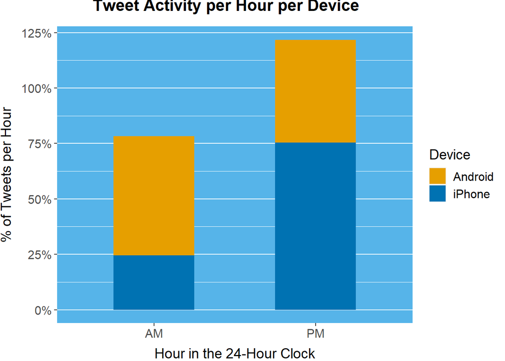

```r
graph <- train_tweets %>%
  select(device, am_pm) %>%
  group_by(device, am_pm) %>%
  summarize(n = n()) %>%
  mutate(percent = n / sum(n)) %>%
  ggplot(aes(am_pm, percent, fill = device)) +
  geom_bar(width = 0.5, stat = "identity") +
  scale_y_continuous(labels = scales::label_percent(accuracy = 1)) +
  ggtitle("Tweet Activity per Hour per Device") +
  labs(x = "Hour in the 24-Hour Clock",
       y = "% of Tweets per Hour",
       fill = "Device") +
  theme(plot.title = element_text(hjust = 0.4, vjust = 3,
                                  size = 16, face = "bold"),
        axis.title.x = element_text(vjust = -1, size = 14),
        axis.title.y = element_text(vjust = 3, size = 14),
        legend.title = element_text(size = 14),
        axis.text.x = element_text(hjust = 0.5, size = 12),
        axis.text.y = element_text(size = 12),
        legend.text = element_text(size = 12),
        # remove the vertical grid lines
        panel.grid.major.x = element_blank(),
        panel.grid.minor.x = element_blank()) +
  scale_fill_manual(values = duo_Palette) +
  theme(panel.background = element_rect(fill = sky_blue))
graph
```

Clear-cut difference: more than 50 % in am for Android, i.e. more than twice as much than iPhone. Would that stay per hour in the 24-hour clock?

Let’s investigate tweet concentration per hour in the 24-hour clock.

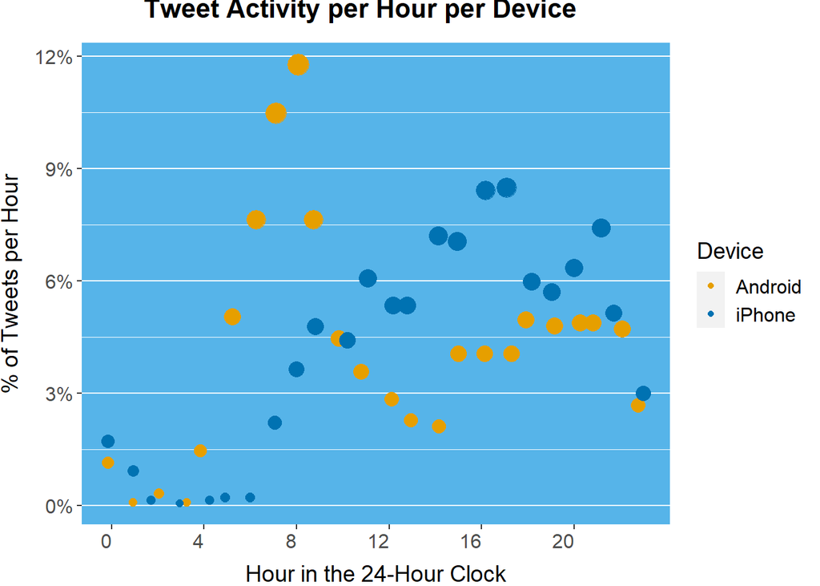

```r
# Preparing tick values and labels for x axis.
seq_ticks <- seq(min(train_tweets$hour), max(train_tweets$hour), 4)

graph <- train_tweets %>%
  select(device, hour) %>%
  group_by(device, hour) %>%
  summarize(n = n()) %>%
  mutate(percent = n / sum(n)) %>%
  ggplot(aes(hour, percent, color = device)) +
  geom_point(aes(size = percent),
             position = position_jitter(width = 0.3, height = 0,
                                        seed = 1)) +
  scale_size_continuous(range = c(2, 6)) +    # Size of dots
  guides(size = FALSE) +                      # No legend for size
  scale_x_continuous(breaks = seq_ticks, labels = waiver()) +
  scale_y_continuous(labels = scales::label_percent(accuracy = 1)) +
  ggtitle("Tweet Activity per Hour per Device") +
  labs(x = "Hour in the 24-Hour Clock",
       y = "% of Tweets per Hour",
       color = "Device") +
  theme(plot.title = element_text(hjust = 0.4, vjust = 3,
                                  size = 16, face = "bold"),
        axis.title.x = element_text(vjust = -1, size = 14),
        axis.title.y = element_text(vjust = 3, size = 14),
        legend.title = element_text(size = 14),
        axis.text.x = element_text(hjust = 1, size = 12),
        axis.text.y = element_text(size = 12),
        legend.text = element_text(size = 12),
        # remove the vertical grid lines
        panel.grid.major.x = element_blank(),
        panel.grid.minor.x = element_blank()) +
  scale_color_manual(values = duo_Palette) +
  theme(panel.background = element_rect(fill = sky_blue))
graph
```

We notice a big peak for the Android in early hours of the morning, between 6 and 9 AM (8 according to Raf). There seems to be a clear different in these patterns.

Some previous research has inferred that two different entities are using these two devices. Autonomy has also been assumed. Personnally, I do not see any proof in the graph. Is this graph incompatible with global coordination but specialization in tasks? Anyway, this point is not material to our objective, which is retrieving insights to better attriubte tweets either to the Android device or to the iPhone device.

What matters here is the statistical representativeness of these average day shcedule curves.

Would that mean that average day schedule is actually repetitive?

Or would the days schedule vary, day after day? Or month after month?

Results will be shown under the form of graphs.

```r
# Scale of x tick marks to be incorporated into ggplot2 graphs
seq_ticks_x <- seq(min(train_tweets$hour), max(train_tweets$hour), 4)

# Creating a function to produce series of day schedule graphs.

building_graph_series <-                            # Function name
  function(d, sub_title) {                          # d = sample of days

    tweets_per_day <- train_tweets %>%              # Filtering data
     select(device, day, hour) %>%                  # based on d
     group_by(device, day, hour) %>%
     filter(day %in% d) %>%
     summarize(n = n()) %>%
     as.data.frame()

    l <- list(1)                                    # Storage list
                                                    # for graphs

    for (i in seq_along(d)) {                       # For loop on
                                                    # sample of days d

      buffer <- tweets_per_day %>%                  # Further filtering
        filter(day == d[i]) %>%                     # data for day i.
        as.data.frame()

      seq_ticks_y <-                                # y tick marks
        seq(min(buffer$n), max(buffer$n), 1)
                                                    # Graph for day i
      graph <- buffer %>%                                                          ggplot(aes(hour, n, color = device)) +
        geom_point(aes(size = n)) +                 # Gradience of dots
        scale_size_continuous(range = c(4, 6)) +    # Size of dots
        guides(size = FALSE) +                      # No legend for size
        scale_x_continuous(breaks = seq_ticks_x, labels = waiver()) +
        scale_y_continuous(breaks = seq_ticks_y, labels = waiver()) +
        labs(title = paste("Day", i, ":", d[i], sep = " "),
             subtitle = sub_title,
             x = "Hour in the 24-Hour Clock",
             y = "# of Tweets per Hour",
             color = "Device") +
        theme(plot.title = element_text(hjust = 0.5, vjust = 2,
                                        size = 16, face = "bold"),
              plot.subtitle = element_text(hjust = 0.5, vjust = 3,
                                           size = 12),
              axis.title.x = element_text(vjust = -1, size = 14),
              axis.title.y = element_text(vjust = 3, size = 14),
              legend.title = element_text(size = 14),
              axis.text.x = element_text(hjust = 1, size = 12),
              axis.text.y = element_text(size = 12),
              legend.text = element_text(size = 12)) +
              scale_color_manual(values = duo_Palette) +
              theme(panel.background = element_rect(fill = sky_blue))

    l[[i]] <- graph                                 # Placing output
    }                                               # into list.

marrangeGrob(l, nrow = 1, ncol = 1, top = "")       # Printing graphs.
}
```

The corresponding 48 day schedule graphs have been produced and analyzed. For illustrative purposes, some of them are reproduced below:

- 4 graphs picked up at random,
- 2 graphs with the top days in global activity,
- 2 graphs with the top days in Android activity,
- 2 graphs with the top days in iPhone activity.

Conclusions drawn on the basis of the 48 graphs or on the basis of the 10 graphs are the same. Let’s examine the 10 graphs, group by group. Let’s get started with the 4 graphs produced at random.

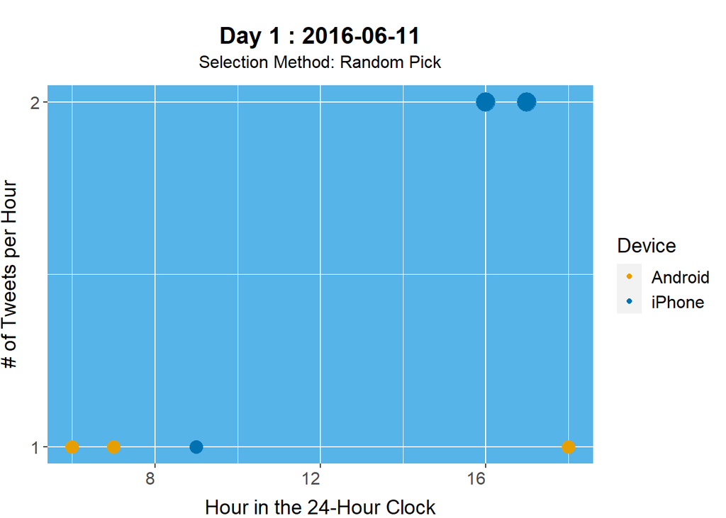

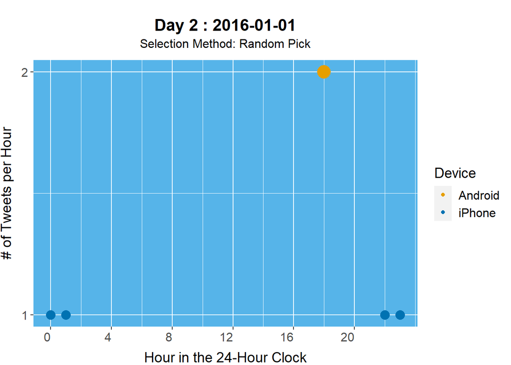

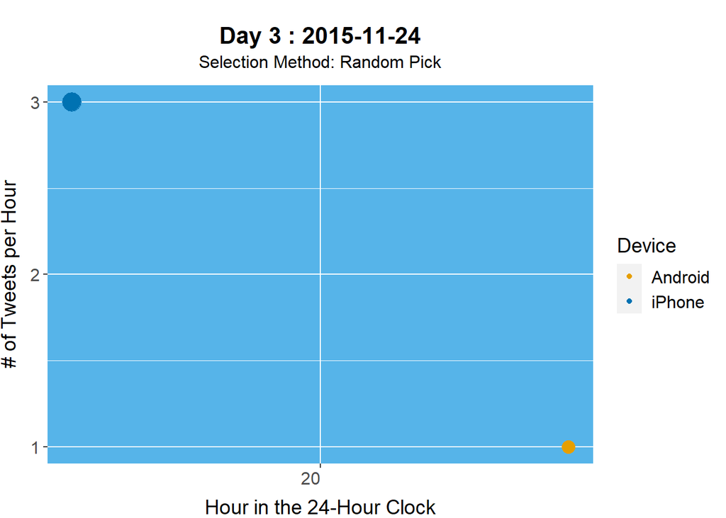

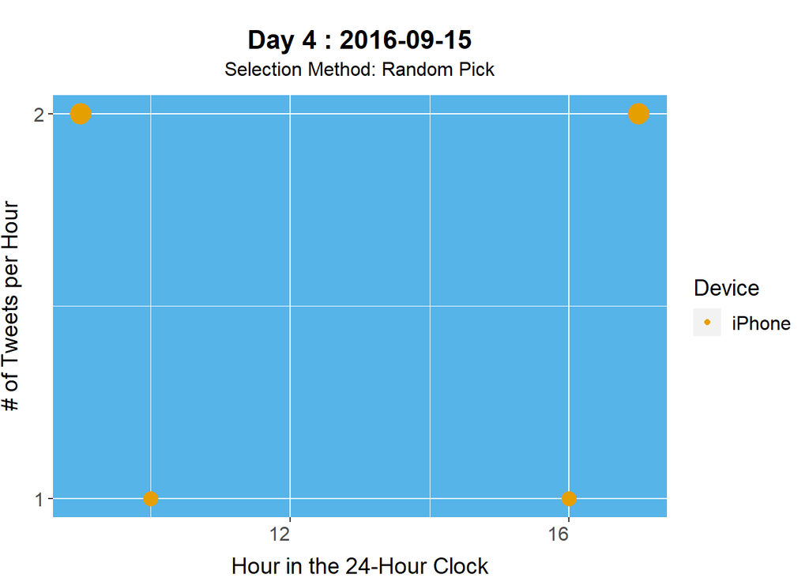

```r
# Let's pick up row numbers at random.
sample_size <- 4
days <- unique(train_tweets$day)
set.seed(1)
sample_r <- sample(days, sample_size, replace = FALSE)
# Let's store day identification in the vector sample_r ("r" for random).

sub_title <- "Selection Method: Random Pick"

building_graph_series(sample_r, sub_title)
```

In day 1, Android activity spread in the morning and in the evening.

Let’s turn to the top activy days.

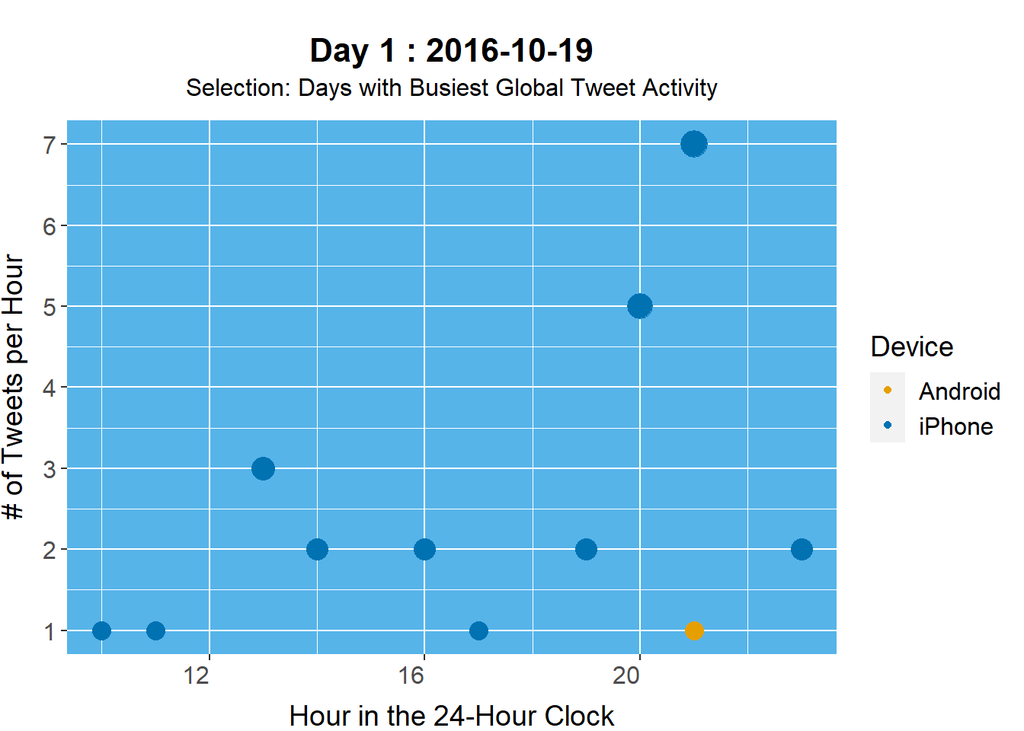

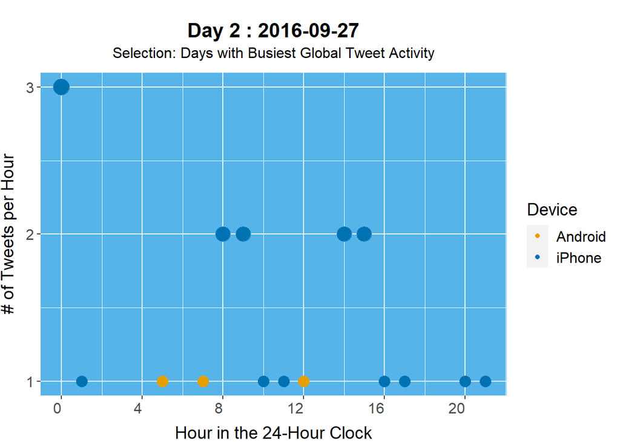

```r
# Let's build up a sample based on global tweet activity per day,
# called sample_g, g being for "global tweet activity".
sample_size <- 2
sample_g <- train_tweets %>%
  select(day) %>%
  filter(!day %in% sample_r) %>%
  group_by(day) %>%
  summarise(n = n()) %>%
  arrange(desc(n)) %>%
  head(., sample_size)

# Keeping the 2 top days for printed graphs.
d <- sample_g$day

sub_title <- "Selection: Days with Busiest Global Tweet Activity"

building_graph_series(d, sub_title)
```

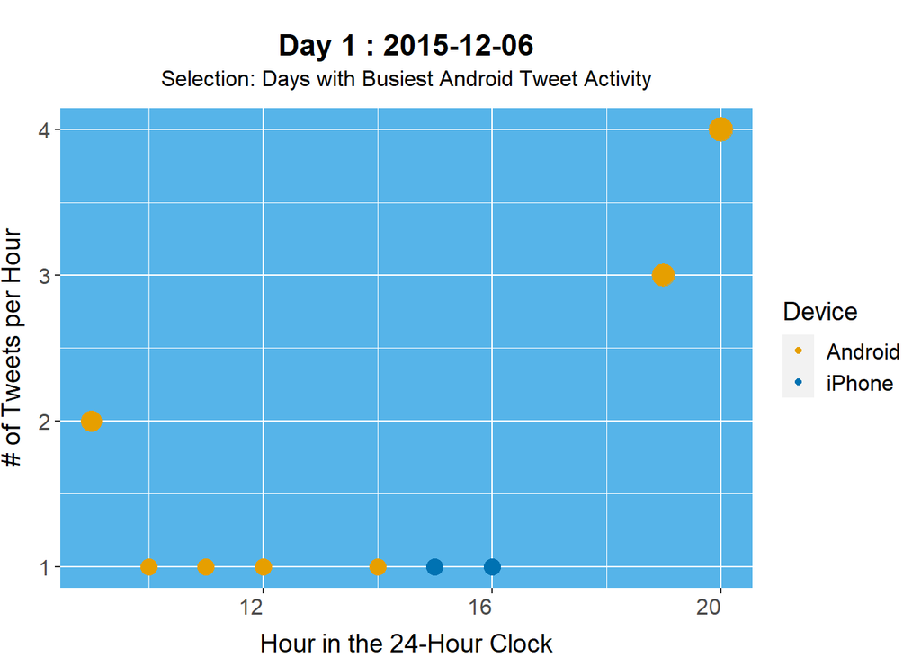

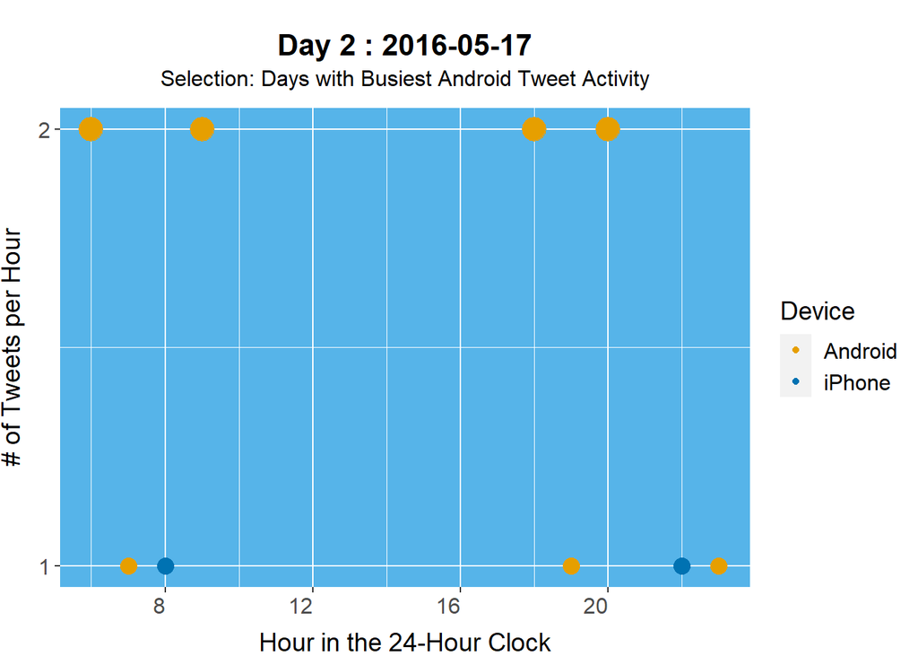

```r
# Vector of days
days <- unique(train_tweets$day)

# Excluding the 2 day vectors previously used.


# Let's build up a sample based on global tweet activity per day,
# called sample_g, a being for "Android tweet activity".
sample_size <- 2
sample_a <- train_tweets %>%
  filter(device == "Android") %>%
  select(day) %>%
  filter(!day %in% sample_r &
           !day %in% sample_g$day) %>%
  group_by(day) %>%
  summarise(n = n()) %>%
  arrange(desc(n)) %>%
  head(., sample_size)

# Keeping the 2 top days for printed graphs.
d <- sample_a$day

sub_title <- "Selection: Days with Busiest Android Tweet Activity"

building_graph_series(d, sub_title)
```

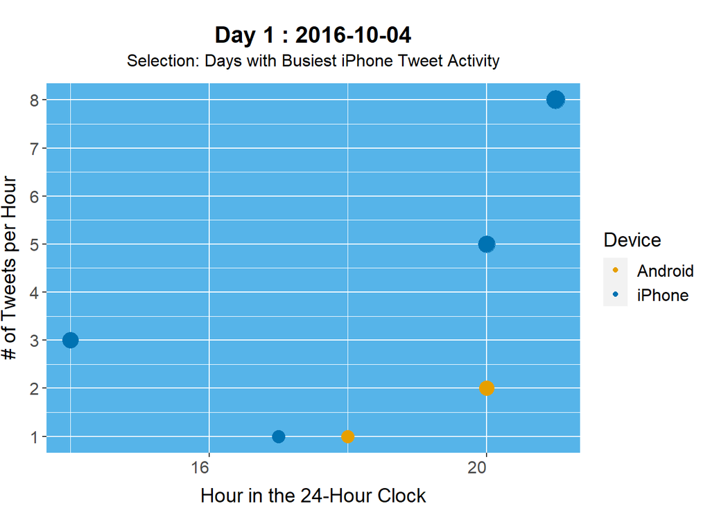

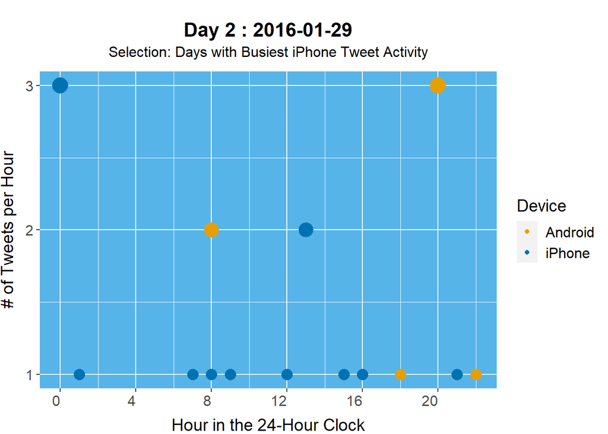

```r
# Vector of days
days <- unique(train_tweets$day)

# Let's build up a sample based on global tweet activity per day,
# called sample_i, i being for "iPhone tweet activity".
sample_size <- 2
sample_i <- train_tweets %>%
  filter(device == "iPhone") %>%
  select(day) %>%
  filter(!day %in% sample_r &
           !day %in% sample_g$day &
           !day %in% sample_a$day) %>%
  group_by(day) %>%
  summarise(n = n()) %>%
  arrange(desc(n)) %>%
  head(., sample_size)

# Keeping the 2 top days for printed graphs.
d <- sample_i$day

sub_title <- "Selection: Days with Busiest iPhone Tweet Activity"

building_graph_series(d, sub_title)
```

Visual evidence provided by the 10 day schedule graphs suggests rather great variety in day schedule away from average day schedules per device.

Let’s get broader insights about dayly time schedule, using the whole dataset. We’ve illustrated variety, let’s now illustrate proximity.

Hour slots

```r
df <- train_tweets %>%                            # Temporary data frame
  select(device, id_str, created_at, hour)

df_android <- df %>%                              # Android only
  filter(device == "Android") %>%
  select(- device)

df_android_short <- df_android                    # Excluding tweets
                                                  # between 12pm & 3pm

df_iphone <- df %>%                               # iPhone only
  filter(device == "iPhone") %>%
  select(- device)

df_iphone_short <- df_iphone %>%                  # Excluding tweets
  filter(hour < 12 | hour >= 15)                  # between 12pm & 3pm

intermingling_measurement <-
  function(lower_limit, df1, df2) {

    coex <- vector(mode = "character", length = 0)

    for (i in 1:nrow(df1)) {
      date_ref <- df1$created_at[i]
      temp <- df2 %>%
        mutate(diff = difftime(created_at, date_ref, units = "hours"))
      diff_pos <- which(temp$diff > 0 &
                        temp$diff <= lower_limit, arr.ind = TRUE)
      diff_neg <- which(temp$diff < 0 &
                        temp$diff >= -lower_limit, arr.ind = TRUE)
      index <- append(diff_pos, diff_neg)

      if(length(index) > 0) {
        prox <- append(df1$id_str[i], df2$id_str[index])
        coex <- append(coex, prox)
      }
    }

    coex <- unique(coex)

    # How many from Android?
    split_coex <- train_tweets %>%
      filter(id_str %in% coex) %>%
      select(device) %>%
      group_by(device) %>%
      summarise(n = n())
    split_coex
  }

intermingling_measurement(1, df_android, df_iphone)
```

| device | n |
| --- | --- |
| Android | 186 |
| iPhone | 191 |

```r
intermingling_measurement(2, df_android, df_iphone)
```

| device | n |
| --- | --- |
| Android | 324 |
| iPhone | 350 |

```r
intermingling_measurement(3, df_android, df_iphone)
```

| device | n |
| --- | --- |
| Android | 422 |
| iPhone | 453 |

```r
intermingling_measurement(4, df_android, df_iphone)
```

| device | n |
| --- | --- |
| Android | 494 |
| iPhone | 558 |

```r
intermingling_measurement(1, df_android_short, df_iphone_short)
```

| device | n |
| --- | --- |
| Android | 169 |
| iPhone | 160 |

```r
intermingling_measurement(2, df_android_short, df_iphone_short)
```

| device | n |
| --- | --- |
| Android | 301 |
| iPhone | 298 |

```r
intermingling_measurement(3, df_android_short, df_iphone_short)
```

| device | n |
| --- | --- |
| Android | 391 |
| iPhone | 381 |

```r
intermingling_measurement(4, df_android_short, df_iphone_short)
```

| device | n |
| --- | --- |
| Android | 446 |
| iPhone | 456 |

This is a try to quantify intermingling between Android tweets and iPhone tweets. On that basis, intermingling, proximity, has been evaluated at more than one fourth, or even on third if all tweets are taken into account.

In a snapshot, day schedule has shown variety away from the average day schedule per device. On the contrary, some temporal proximity has been shown in one fourth or even one third of tweets. Publication time will be used as a predictor to attribute tweets, in hour format or am-pm.

But would day schedule also vary month after month? Let’s try to retrieve pre-attentive insights from drawing am-pm breakdown per month and per device.